# Term Deposit Sale Project

#### Data Analysis and Modelling by: Varun Kulkarni (kulkarnivarun@outlook.com)

## Goal

Using the data collected from existing customers, build a model that will help the marketing team identify potential customers who are relatively more likely to subscribe term deposit and thus increase their hit ratio.

## Data Source

bank-full.csv (https://archive.ics.uci.edu/ml/datasets/Bank+Marketing)

## Tasks

- Exploratory Data Analysis
  - Univariate Analysis
  - Multivariate Analysis
- Prepare Data for Analytics
  - Ensure the attribute types are correct
  - Transform the data i.e. scale / normalize if required
  - Create training set and test set in ratio of 70:30
- Create Ensemble Models
  - Logistic Regression Model
  - Decision Tree Model
  - Ensemble Model using Bagging
  - Ensemble Model using Random Forest
  - Ensemble Model using Adaptive Boosting
  - Ensemble Model using Gradient Boosting
  - Comparing All Models
- Conclusion

```python
# Import required libraries
import pandas as pd
import numpy as np
import matplotlib.pyplot as plt
import scipy.stats as stats
import seaborn as sns
import warnings
from IPython.display import Image
from os import system

# Import rtelevant utilities from sklearn
from sklearn.model_selection import train_test_split
from sklearn.metrics import f1_score, recall_score, precision_score, confusion_matrix, roc_auc_score
from sklearn import tree
from sklearn.preprocessing import RobustScaler

# Import relevant models from sklearn
from sklearn.linear_model import LogisticRegression
from sklearn.tree import DecisionTreeClassifier
from sklearn.ensemble import BaggingClassifier
from sklearn.ensemble import RandomForestClassifier
from sklearn.ensemble import AdaBoostClassifier
from sklearn.ensemble import GradientBoostingClassifier

# Environment and global settings
%matplotlib inline
sns.set(color_codes=True)
warnings.filterwarnings('ignore')
RANDOM_STATE=42
NUM_ESTIMATORS=50
```

## Exploratory Data Analysis

In this section we will look at characteristics and distributions of given variables. Explore co-relations between various independent variables and how they impact the target variable.

```python
# Import dataset and get familiar with the data
bank_df = pd.read_csv('bank-full.csv')
bank_df.head()
```

|  | age | job | marital | education | default | balance | housing | loan | contact | day | month | duration | campaign | pdays | previous | poutcome | Target |
| --- | --- | --- | --- | --- | --- | --- | --- | --- | --- | --- | --- | --- | --- | --- | --- | --- | --- |
| 0 | 58 | management | married | tertiary | no | 2143 | yes | no | unknown | 5 | may | 261 | 1 | -1 | 0 | unknown | no |
| 1 | 44 | technician | single | secondary | no | 29 | yes | no | unknown | 5 | may | 151 | 1 | -1 | 0 | unknown | no |
| 2 | 33 | entrepreneur | married | secondary | no | 2 | yes | yes | unknown | 5 | may | 76 | 1 | -1 | 0 | unknown | no |
| 3 | 47 | blue-collar | married | unknown | no | 1506 | yes | no | unknown | 5 | may | 92 | 1 | -1 | 0 | unknown | no |
| 4 | 33 | unknown | single | unknown | no | 1 | no | no | unknown | 5 | may | 198 | 1 | -1 | 0 | unknown | no |

### Univariate Analysis

```python
# Shape of the dataset
print("There are {0} records and {1} variables.".format(bank_df.shape[0], bank_df.shape[1]))

# Check for null values
if bank_df.isnull().values.any():
    print("Null values found!")
else:
    print("No null values found.")

# Check for NA values
if bank_df.isna().values.any():
    print("NA values found!")
else:
    print("No NA values found.")

# Check for duplicated values
print("Number of duplicated records: ", bank_df.duplicated().sum())
```

```
There are 45211 records and 17 variables.
No null values found.
No NA values found.
Number of duplicated records:  0
```

```python
# Check data types, counts, etc.
bank_df.info()
```

```
<class 'pandas.core.frame.DataFrame'>
RangeIndex: 45211 entries, 0 to 45210
Data columns (total 17 columns):
 #   Column     Non-Null Count  Dtype
---  ------     --------------  -----
 0   age        45211 non-null  int64
 1   job        45211 non-null  object
 2   marital    45211 non-null  object
 3   education  45211 non-null  object
 4   default    45211 non-null  object
 5   balance    45211 non-null  int64
 6   housing    45211 non-null  object
 7   loan       45211 non-null  object
 8   contact    45211 non-null  object
 9   day        45211 non-null  int64
 10  month      45211 non-null  object
 11  duration   45211 non-null  int64
 12  campaign   45211 non-null  int64
 13  pdays      45211 non-null  int64
 14  previous   45211 non-null  int64
 15  poutcome   45211 non-null  object
 16  Target     45211 non-null  object
dtypes: int64(7), object(10)
memory usage: 5.9+ MB
```

```python
# Let's look at the 5-point summary for numerical attributes
bank_df.describe().T
```

|  | count | mean | std | min | 25% | 50% | 75% | max |
| --- | --- | --- | --- | --- | --- | --- | --- | --- |
| age | 45211.0 | 40.936210 | 10.618762 | 18.0 | 33.0 | 39.0 | 48.0 | 95.0 |
| balance | 45211.0 | 1362.272058 | 3044.765829 | -8019.0 | 72.0 | 448.0 | 1428.0 | 102127.0 |
| day | 45211.0 | 15.806419 | 8.322476 | 1.0 | 8.0 | 16.0 | 21.0 | 31.0 |
| duration | 45211.0 | 258.163080 | 257.527812 | 0.0 | 103.0 | 180.0 | 319.0 | 4918.0 |
| campaign | 45211.0 | 2.763841 | 3.098021 | 1.0 | 1.0 | 2.0 | 3.0 | 63.0 |
| pdays | 45211.0 | 40.197828 | 100.128746 | -1.0 | -1.0 | -1.0 | -1.0 | 871.0 |
| previous | 45211.0 | 0.580323 | 2.303441 | 0.0 | 0.0 | 0.0 | 0.0 | 275.0 |

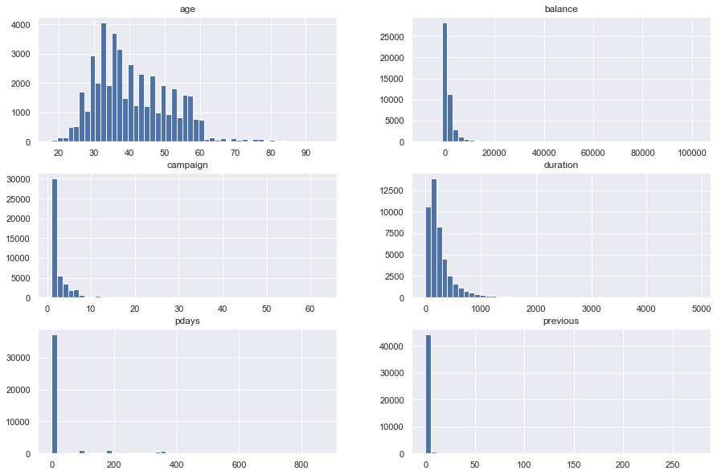

```python
# Let's look at the disribution of numerical variables

# Although 'day' has numerical values, it seems to be a categorical variable with ordinal values
numerical_vars = ['age', 'balance', 'duration', 'campaign', 'pdays', 'previous']
bank_df.hist(column=numerical_vars, figsize=(15,10), bins=50)
plt.subplots_adjust(wspace=0.25, hspace=0.25)
plt.show()
```

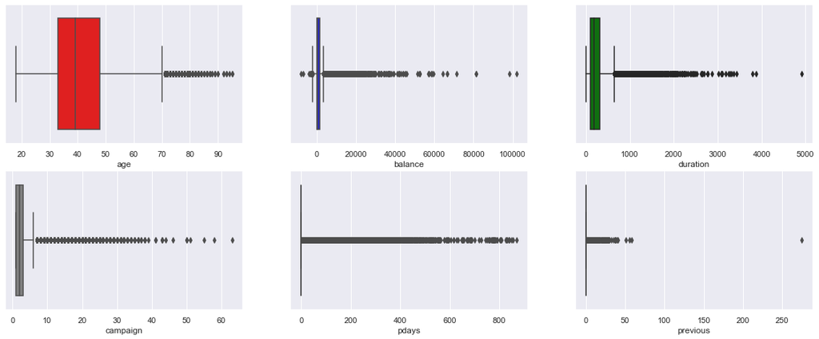

```python
# Let's analyze the continuous variables futher, by looking at their IQRs using box plots
colors = ['red', 'blue', 'green', 'grey', 'yellow', 'orange']
idx = 1

plt.figure(figsize= (20,12))
for var, color in zip(numerical_vars, colors):
    plt.subplot(3, 3, idx)
    sns.boxplot(x=bank_df[var], color=color);
    idx += 1
```

```python
# Let's look at the skewness for numerical variables
skewness_df = pd.DataFrame({'Skewness Value': [stats.skew(bank_df[var]) for var in numerical_vars]},
                           index=numerical_vars)
skewness_df.T
```

|  | age | balance | duration | campaign | pdays | previous |
| --- | --- | --- | --- | --- | --- | --- |
| Skewness Value | 0.684795 | 8.360031 | 3.144214 | 4.898488 | 2.615629 | 41.845066 |